# IE0127 Proyecto: Diseño de un generador de reporte gráfico del COVID-19 en Costa Rica a nivel cantonal

Mike Mai Chen

22 de julio de 2021

## Introducción

El proyecto consiste en crear un programa que genere gráficamente un reporte de los datos del COVID-19 a nivel cantonal en el país para un rango de fechas definido por el usuario. Para empezar, se utiliza pandas y geopandas, así como sus métodos para importar y procesar los datos del COVID-19 y los datos geográficos de cada cantón, respectivamente. Seguidamente, para trabajar con las fechas se usa el módulo datetime. Finalmente, para generar los gráficos y el reporte como tal se usa el matplotlib.

El programa consiste a grandes rasgos tres partes: importar los datos a data frames; procesar y limpiar los data frames; y por último, generar los elementos gráficos. El enlace al proyecto se encuentra hosteado en [Github](https://github.com/madlee08/IE0217_project).

## Fuentes de dato

### Datos del COVID-19

Los datos del COVID-19 a nivel cantonal se obtuvieron a partir de los archivos publicados por el Ministerio de Salud y hosteados por el [Observatorio Geográfico en Salud](http://geovision.uned.ac.cr/oges/index.html).

[figure not shown]

### Datos de los límites administrativos cantonales

La geometría (datos geográfico) del país que describe los límites administrativos a nivel cantonal se puede solicitar en el [Instituto Geográfico Nacional](http://www.registronacional.go.cr/instituto_geografico/index.htm). Sin embargo, el plazo de entrega es de 10 días hábiles. Una fuente alternativa, que este proyecto utilizó, es por medio de [Open Street Maps](https://osm-boundaries.com/).

[figure not shown]

## Módulos necesarios

A continuación se muestran los módulos necesarios para desarrollar el proyecto:

```python
import geopandas as gpd
import pandas as pd
import matplotlib.pyplot as plt
from datetime import date, datetime, timedelta
from matplotlib.backends.backend_pdf import PdfPages
```

### Geopandas

Geopandas es un módulo que extiende las funcionalidades del pandas agregando soporte para datos geográficos (como los límites administrativos de un país) a los data frames del pandas. Un data frame con datos geográficos se denomina **geodata frame**. Los datos geográficos de dicho geodata frame generalmente se encuentra en una columna del geodata frame denominado **geometry**, que describe la geometría de cualquier objeto geográfico.

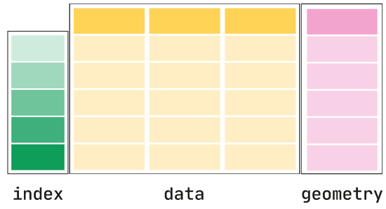

Las libería geopandas se puede obtener por medio de **anaconda** con el comando `conda install -c conda-forge geopandas` y la documentación se puede acceder [aquí](https://geopandas.org/index.html).

### Datetime

El módulo de datetime permite realizar operaciones con fechas, ya sea suma, resta o incluso comparar entre dos fechas. El tipo de datos que con que trabaja el módulo es de tipo datetime. La documentación se puede encontrar [aquí](https://docs.python.org/3/library/datetime.html).

### PdfPages

Este módulo se utiliza en el proyecto puesto que permite exportar a un pdf las figuras generadas por el plot de matplotlib.

## Clases utilizadas para el proyecto

Seguidamente se detallan las clases utilizadas para el proyecto.

### Clase `importar_arxivs`

Esta clase base se encarga de asegurar que el archivo a importar tenga la extensión adecuada. Si no cumple las extensiones válidas, entonces arrojará una excepción.

```python
class importar_arxivs:
    def __init__(self, ruta_de_archivo):
        valido = False
        for extension in self.extensiones:
            if ruta_de_archivo.endswith(extension):
                valido = True

        if not valido:
            raise Exception('Formato incorrecto')
        self.ruta = ruta_de_archivo
```

#### Clases heredadas de `importar_arxivs`

Por herencia se crean las siguientes tres clases, cada uno con su lista de extensiones válidas.

```python
class importar_csv(importar_arxivs):
    extensiones = ['csv']

    def importar(self):
        return pd.read_csv(self.ruta)

class importar_excel(importar_arxivs):
    extensiones = ['xls', 'xlsx', 'xlsm', 'xlsb', 'odf', 'odt']

    def importar(self, hoja=0):
        return pd.read_excel(self.ruta, sheet_name=hoja)

class importar_geodata(importar_arxivs):
    extensiones = ['shp', 'gpkg', 'geojson']

    def importar(self):
        return gpd.read_file(self.ruta)
```

### Clase `importar_a_pd`

Esta clase se encarga de juntar las tres clases anteriores en tres métodos.

```python
class importar_a_pd:
    def excel(self, ruta_de_archivo, hoja=0):
        arxiv_excel = importar_excel(ruta_de_archivo)
        return arxiv_excel.importar(hoja=hoja)

    def csv(self, ruta_de_archivo):
        arxiv_csv = importar_csv(ruta_de_archivo)
        return arxiv_csv.importar()

    def geodata(self, ruta_de_archivo):
        arvix_geojson = importar_geodata(ruta_de_archivo)
        return arvix_geojson.importar()
```

### Clase `DFs_base`

Es clase solamente incluye dos diccionarios, que se utilizan para crear y manejar varios data frames. La `lista_df` almacena todos los data frames y la `lista_df_limpio` almacena solamente los data frames que se utilizarán para gráficas.

```python
class DFs_base:
    lista_df = dict()
    lista_df_limpio = dict()
```

#### Clase `DFs_procesar`

Por herencia se crea la clase `DFs_procesar` donde se implementa los métodos para procesar y manipular los data frames.

```python
class DFs_procesar (DFs_base):
    importar = importar_a_pd()

    def agregar_excel(self, df_nombre_nuevo, ruta_de_archivo, hoja=0):
        self.lista_df[df_nombre_nuevo] = self.importar.excel(ruta_de_archivo, hoja=hoja)

    def agregar_csv(self, df_nombre_nuevo, ruta_de_archivo):
        self.lista_df[df_nombre_nuevo] = self.importar.csv(ruta_de_archivo)

    def agregar_geodata(self, gdf_nombre_nuevo, ruta_de_archivo):
        self.lista_df[gdf_nombre_nuevo] = self.importar.geodata(ruta_de_archivo)

    def remover_indices(self, df_nombre, lista_de_indices):
        self.lista_df[df_nombre].drop(lista_de_indices, inplace=True)

    def remover_columnas(self, df_nombre, lista_de_columnas, invertido=False):
        if not invertido:
            self.lista_df[df_nombre].drop(lista_de_columnas, inplace=True, axis=1)
        else:
            self.lista_df[df_nombre] = self.lista_df[df_nombre][self.lista_df[df_nombre].columns.intersection(lista_de_columnas)]

    def renombrar_columnas(self, df_nombre, lista_de_columnas):
        self.lista_df[df_nombre].rename(columns=lista_de_columnas, inplace=True)

    def fusionar_dfs(self, df_nombre_nuevo, df_nombre1, df_nombre2, pivote):
        self.lista_df_limpio[df_nombre_nuevo] = self.lista_df[df_nombre1].merge(self.lista_df[df_nombre2], on=pivote)

    def agregar_columna(self, df_nombre, nombre_columna_nuevo, valores):
        self.lista_df[df_nombre][nombre_columna_nuevo] = valores

    def fijar_indice(self, df_nombre, nombre_columna):
        self.lista_df[df_nombre].set_index(nombre_columna, inplace=True)

    def columnas_a_datetime(self, df_nombre):
        columnas = self.lista_df[df_nombre].columns
        self.lista_df[df_nombre].columns = pd.to_datetime(columnas, infer_datetime_format=True)

    def devolver_columnas(self, df_nombre):
        return self.lista_df[df_nombre].columns.to_list()

    def imprimir_df(self):
        for df in self.lista_df.keys():
            print(self.lista_df[df])

    def imprimir_df_limpio(self):
        for df in self.lista_df_limpio.keys():
            print(self.lista_df_limpio[df])

    def agregar_diff_columna(self, df_nombre, nombre_columna_nuevo, fecha_inicial, fecha_final):
        columnas = self.devolver_columnas(df_nombre)

        primero = columnas[0]
        ultimo = columnas[-1]

        if fecha_inicial != fecha_final:
            diff = self.lista_df[df_nombre][ultimo] - self.lista_df[df_nombre][primero]
        else:
            diff = self.lista_df[df_nombre][primero]

        self.agregar_columna(df_nombre, nombre_columna_nuevo, diff)

    def agregar_media_columna(self, df_nombre, nombre_columna_nuevo):
        media = self.lista_df[df_nombre].mean(axis=1)
        self.agregar_columna(df_nombre, nombre_columna_nuevo, media)
```

#### Clase `DFs_graficar`

Por otro lado, por herencia se crea la clase `DFs_graficar` que se encarga de crear y exportar los elementos gráficos.

```python
class DFs_graficar(DFs_base):
    output_archivo = str()
    lista_fig = list()

    def graficar_df(self, df_nombre, columna, color, fecha_inicial, fecha_final):
        drop, indicador = df_nombre.split('-')
        fig, (ax1, ax2) = plt.subplots(1,2, figsize=(8,4))

        leyenda = str()

        if fecha_inicial == fecha_final:
            self.output_archivo = 'Reporte_{}'.format(fecha_inicial)

            leyenda = 'Casos {} por canton'.format(indicador)
            fig.suptitle(leyenda + '\npara el dia {}'.format(fecha_inicial))

        else:
            self.output_archivo = 'Reporte_{}_{}'.format(fecha_inicial,fecha_final)

            if indicador == 'activos' or indicador == 'nuevos':
                leyenda = 'Casos {} promedio por canton'.format(indicador)
                fig.suptitle(leyenda + '\ndesde {} hasta {}'.format(fecha_inicial, fecha_final))

            else:
                leyenda = 'Diferencia de casos {} por canton'.format(indicador)
                fig.suptitle(leyenda + '\ndesde {} hasta {}'.format(fecha_inicial, fecha_final))

        self.lista_df_limpio[df_nombre].plot(columna, cmap=color, edgecolor ='k', linewidth = 0.5, ax=ax1)
        ax1.set_xlim(-86.1, -82.5)
        ax1.set_ylim(8, 11.3)
        ax1.set_xticks([])
        ax1.set_yticks([])
        ax1.set_title('Vista general')

        self.lista_df_limpio[df_nombre].plot(columna, cmap=color, edgecolor ='k', linewidth = 0.5, ax=ax2, legend=True, legend_kwds={'label':leyenda, 'orientation':'vertical'})
        ax2.set_xlim(-84.4, -83.7)
        ax2.set_ylim(9.7, 10.3)
        ax2.set_xticks([])
        ax2.set_yticks([])
        ax2.set_title('Cantones de la GAM')

        self.lista_fig.append(fig)

    def crear_pdf(self, nombre_archivo=''):
        if nombre_archivo =='':
            nombre_archivo = self.output_archivo

        with PdfPages('../output/'+nombre_archivo+'.pdf') as pdf:
            for fig in self.lista_fig:
                pdf.savefig(fig)
```

### Clase `formato_fechas`

Esta clase se encarga de convertir un string de fechas a formato datetime y trabaja con datos de tipo datetime. Adicionalmente agrega flexibilidad a la hora de escribir el rango de fechas que el usuario desea generar el reporte.

```python
class formato_fechas:
    def __init__(self, fecha_inicial, fecha_final, fecha_archivo):
        self.fecha_max = self.datetime_max(fecha_archivo)
        self.fecha_min = date(2020, 4, 21)

        if fecha_inicial.isnumeric() and not fecha_final.isnumeric():
            self.fin = self.str_a_datetime_final(fecha_final)
            self.inicio = self.str_a_datetime_inicial(fecha_inicial)

        else:
            self.inicio = self.str_a_datetime_inicial(fecha_inicial)
            self.fin = self.str_a_datetime_final(fecha_final)

        self.lista_dias = self.rango_dias(self.inicio, self.fin)

    def datetime_max(self, fecha_max):
        if fecha_max == '':
            hoy = datetime.now()
            hoy20horas = hoy.replace(hour=20, minute=0, second=0, microsecond=0)

            if hoy < hoy20horas:
                return date.today() + timedelta(days=-1)
            else:
                return date.today()
        else:
            dia, mes, anio = fecha_max.split('/')
            return date(int(anio), int(mes), int(dia))

    def str_a_datetime_inicial(self, fecha_inicial):
        if fecha_inicial !='' and not fecha_inicial.isnumeric():
            dia, mes, anio = fecha_inicial.split('/')
            fecha_inicio = date(int(anio), int(mes), int(dia))

            if fecha_inicio < self.fecha_min:
                fecha_inicio = self.fecha_min
            return fecha_inicio

        elif fecha_inicial =='':
            return self.fecha_max

        elif fecha_inicial.isnumeric():
            fecha_inicio = self.fin + timedelta(days=-int(fecha_inicial))

            if fecha_inicio < self.fecha_min:
                fecha_inicio = self.fecha_min
            return fecha_inicio

    def str_a_datetime_final(self, fecha_final):
        if fecha_final !='' and not fecha_final.isnumeric():
            dia, mes, anio = fecha_final.split('/')
            fecha_fin = date(int(anio), int(mes), int(dia))

            if fecha_fin > self.fecha_max:
                fecha_fin = self.fecha_max
            return fecha_fin

        elif fecha_final =='':
            return self.fecha_max

        elif fecha_final.isnumeric():
            fecha_fin =  self.inicio + timedelta(days=int(fecha_final))

            if fecha_fin > self.fecha_max:
                fecha_fin = self.fecha_max
            return fecha_fin

    def rango_dias(self, fecha_inicial, fecha_final):
        return pd.date_range(start=fecha_inicial, end=fecha_final).to_list()

    def get_fecha_max(self):
        return self.fecha_max

    def get_fecha_inicial(self):
        return self.inicio

    def get_fecha_final(self):
        return self.fin

    def get_lista_dias(self):
        return self.lista_dias
```

### Clase `get_str_fecha`

Esta clase convierte datos de tipo datetime a strings, es decir, hace operaciones inversas respecto a la clase anterior.

```python
class get_str_fecha:
    def __init__(self, fecha_datetime):
        self.fecha = fecha_datetime

    def get_dia_str(self):
        dia = str()

        if self.fecha.day in range(1, 10):
            dia = '0' + str(self.fecha.day)

        else:
            dia = str(self.fecha.day)

        return dia

    def get_mes_str(self):
        mes = str()

        if self.fecha.month in range(1, 10):
            mes = '0' + str(self.fecha.month)

        else:
            mes = str(self.fecha.month)

        return mes

    def get_anio_str(self, corto=False):
        anio = str()

        if corto:
            anio = str(self.fecha.year - 2000)

        else:
            anio = str(self.fecha.year)

        return anio
```

### Clase `DFs`

Esta clase es la clase principal que utiliza todas las clases definidos anteriormente.

```python
class DFs (DFs_procesar, DFs_graficar):
    def __init__(self, fecha_inicial='', fecha_final='', fecha_archivo='', indicadores=['positivos', 'activos', 'recup', 'fallecidos'], mostrar_graficas=False, verboso=False):
        fecha = formato_fechas(fecha_inicial, fecha_final, fecha_archivo)

        self.fecha_max = fecha.get_fecha_max()
        self.fecha_inicial = fecha.get_fecha_inicial()
        self.fecha_final = fecha.get_fecha_final()
        self.lista_dias = fecha.get_lista_dias()

        self.indicadores = indicadores
        self.mostrar_graficas = mostrar_graficas
        self.verboso = verboso

    def main(self):
        self.agregar_datos()
        self.limpiar_datos()
        self.fusionar_datos()
        self.graficar_datos()
        self.pdf()
        if self.mostrar_graficas:
            plt.show()
        plt.close()

    def agregar_datos(self):
        self.agregar_geodata('cantones', '../Datos/costa_rica_cantones.geojson')
        self.agregar_csv('nombres', '../Datos/costa_rica_cantones_nombres.csv')

        if self.verboso:
            print('='*70)
            print('GEODATAFRAME AGREGADO')
            print('='*70)
            print(self.lista_df['cantones'])
            print('='*70)
            print()

        fecha = get_str_fecha(self.fecha_max)

        anio_corto = fecha.get_anio_str(corto=True)
        mes = fecha.get_mes_str()
        dia = fecha.get_dia_str()

        for indicador in self.indicadores:
            self.agregar_csv(indicador, '../Datos/{}_{}_{}_CSV_{}.csv'.format(mes, dia, anio_corto, indicador.upper()))

            if self.verboso:
                print('='*70)
                print('DATAFRAME DEL INDICADOR {} AGREGADO'.format(indicador))
                print('='*70)
                print(self.lista_df[indicador])
                print('='*70)
                print()

    def limpiar_datos(self):
        if self.verboso:
            print('='*70)
            print('MODIFICANDO GEODATAFRAME')
            print('='*70)
            print()

        self.remover_columnas('cantones', ['local_name', 'geometry'], invertido=True)

        if self.verboso:
            print(self.lista_df['cantones'])
            print('='*70)

        self.renombrar_columnas('cantones', {'local_name':'canton'})

        if self.verboso:
            print(self.lista_df['cantones'])
            print('='*70)

        self.fijar_indice('cantones', 'canton')
        self.lista_df['cantones'].index = self.lista_df['cantones'].index.str.replace('Cantón ', '')


        if self.verboso:
            print(self.lista_df['cantones'])
            print('='*70)

        if self.verboso:
            print('='*70)
            print('MODIFICACION DEL GEODATAFRAME FINALIZADO')
            print('='*70)
            print()

        for indicador in self.indicadores:
            if self.verboso:
                print('='*70)
                print('MODIFICANDO DATAFRAME DEL INDICADOR {}'.format(indicador))
                print('='*70)
                print()

            self.remover_columnas(indicador, ['cod_provin', 'provincia', 'cod_canton'])

            if self.verboso:
                print(self.lista_df[indicador])
                print('='*70)

            self.lista_df[indicador].canton = self.lista_df['nombres']

            if self.verboso:
                print(self.lista_df[indicador])
                print('='*70)

            self.fijar_indice(indicador, 'canton')
            self.columnas_a_datetime(indicador)

            if self.verboso:
                print(self.lista_df[indicador])
                print('='*70)

            self.remover_columnas(indicador, self.lista_dias, invertido=True)

            if self.verboso:
                print(self.lista_df[indicador])
                print('='*70)

            if indicador == 'activos' or indicador == 'nuevos':
                self.agregar_media_columna(indicador, 'DATA')

            else:
                self.agregar_diff_columna(indicador, 'DATA', self.fecha_inicial, self.fecha_final)

            if self.verboso:
                print(self.lista_df[indicador])
                print('='*70)

            self.remover_columnas(indicador, ['DATA'], invertido=True)

            if self.verboso:
                print(self.lista_df[indicador])
                print('='*70)

            if self.verboso:
                print('='*70)
                print('MODIFICACION DEL DATAFRAME DEL INDICADOR {} FINALIZADO'.format(indicador))
                print('='*70)
                print()

    def fusionar_datos(self):
        for indicador in self.indicadores:
            df_nombre = 'cantones-' + indicador

            self.fusionar_dfs(df_nombre, 'cantones', indicador, pivote='canton')

            if self.verboso:
                print('='*70)
                print('DATAFRAME FUSIONADO ENTRE CANTONES Y {}'.format(indicador))
                print('='*70)
                print(self.lista_df_limpio[df_nombre])
                print('='*70)
                print()

    def graficar_datos(self):
        if self.verboso:
            print('GRAFICANDO GEODATAFRAMES...')
        lista_colores = {'cantones-activos': 'OrRd', 'cantones-recup': 'Greens', 'cantones-positivos': 'Purples', 'cantones-fallecidos': 'Greys'}

        for key in self.lista_df_limpio.keys():
            self.graficar_df(key, 'DATA', lista_colores[key], self.fecha_inicial, self.fecha_final)

        if self.verboso:
            print('GRAFICACION FINALIZADO')
            print()

    def pdf(self):
        if self.verboso:
            print('CREANDO PDF...')

        self.crear_pdf()

        if self.verboso:
            print('PDF CREADO')
            print()
```

### Clase `DFs` limpio

Una versión más legible de la clase anterior se muestra a continuación:

```python
class DFs (DFs_procesar, DFs_graficar):
    def __init__(self, fecha_inicial='', fecha_final='', fecha_archivo='', indicadores=['positivos', 'activos', 'recup', 'fallecidos'], mostrar_graficas=False, verboso=False):
        fecha = formato_fechas(fecha_inicial, fecha_final, fecha_archivo)

        self.fecha_max = fecha.get_fecha_max()
        self.fecha_inicial = fecha.get_fecha_inicial()
        self.fecha_final = fecha.get_fecha_final()
        self.lista_dias = fecha.get_lista_dias()

        self.indicadores = indicadores
        self.mostrar_graficas = mostrar_graficas
        self.verboso = verboso

    def main(self):
        self.agregar_datos()
        self.limpiar_datos()
        self.fusionar_datos()
        self.graficar_datos()
        self.pdf()
        if self.mostrar_graficas:
            plt.show()
        plt.close()

    def agregar_datos(self):
        self.agregar_geodata('cantones', '../Datos/costa_rica_cantones.geojson')
        self.agregar_csv('nombres', '../Datos/costa_rica_cantones_nombres.csv')

        fecha = get_str_fecha(self.fecha_max)

        anio_corto = fecha.get_anio_str(corto=True)
        mes = fecha.get_mes_str()
        dia = fecha.get_dia_str()

        for indicador in self.indicadores:
            self.agregar_csv(indicador, '../Datos/{}_{}_{}_CSV_{}.csv'.format(mes, dia, anio_corto, indicador.upper()))

    def limpiar_datos(self):
        self.remover_columnas('cantones', ['local_name', 'geometry'], invertido=True)
        self.renombrar_columnas('cantones', {'local_name':'canton'})
        self.fijar_indice('cantones', 'canton')
        self.lista_df['cantones'].index = self.lista_df['cantones'].index.str.replace('Cantón ', '')

        for indicador in self.indicadores:
            self.remover_columnas(indicador, ['cod_provin', 'provincia', 'cod_canton'])
            self.lista_df[indicador].canton = self.lista_df['nombres']
            self.fijar_indice(indicador, 'canton')
            self.columnas_a_datetime(indicador)
            self.remover_columnas(indicador, self.lista_dias, invertido=True)

            if indicador == 'activos' or indicador == 'nuevos':
                self.agregar_media_columna(indicador, 'DATA')

            else:
                self.agregar_diff_columna(indicador, 'DATA', self.fecha_inicial, self.fecha_final)

            self.remover_columnas(indicador, ['DATA'], invertido=True)


    def fusionar_datos(self):
        for indicador in self.indicadores:
            df_nombre = 'cantones-' + indicador

            self.fusionar_dfs(df_nombre, 'cantones', indicador, pivote='canton')

    def graficar_datos(self):
        lista_colores = {'cantones-activos': 'OrRd', 'cantones-recup': 'Greens', 'cantones-positivos': 'Purples', 'cantones-fallecidos': 'Greys'}

        for key in self.lista_df_limpio.keys():
            self.graficar_df(key, 'DATA', lista_colores[key], self.fecha_inicial, self.fecha_final)

    def pdf(self):
        self.crear_pdf()
```

## Ejecución del programa

```python
Data = DFs('7', fecha_archivo='19/07/2021', mostrar_graficas=True, verboso=True)
Data.main()
```

Al llamar al `main()` de la clase `DFs`, este llamará a varios métodos.

### Método `agregar_datos`

Este método consiste en importar a pandas los archivos necesarios. Primero se agrega el archivo que contiene los datos geográficos:

```python
    def agregar_datos(self):
        self.agregar_geodata('cantones', '../Datos/costa_rica_cantones.geojson')
```

```
======================================================================
GEODATAFRAME AGREGADO
======================================================================
     osm_id  ...                                           geometry
0  -6404570  ...  MULTIPOLYGON (((-87.10198 5.50811, -87.10173 5...
1  -6153858  ...  MULTIPOLYGON (((-85.87576 10.35570, -85.87565 ...
2  -5721071  ...  POLYGON ((-84.68936 9.90382, -84.68921 9.90293...
3  -5720555  ...  POLYGON ((-84.74038 9.95316, -84.74036 9.95234...
4  -5366458  ...  POLYGON ((-84.46888 9.93878, -84.46879 9.93837...
..      ...  ...                                                ...
77 -4071270  ...  POLYGON ((-84.18575 9.97157, -84.18537 9.96934...
78 -5672742  ...  POLYGON ((-84.11405 9.97097, -84.11396 9.97094...
79 -6156366  ...  POLYGON ((-85.24957 10.24990, -85.24443 10.244...
80 -5725526  ...  MULTIPOLYGON (((-85.69929 10.61072, -85.69902 ...
81 -5370094  ...  POLYGON ((-84.17379 10.00530, -84.17378 10.005...

[82 rows x 8 columns]
======================================================================
```

y luego se agregan los datos del COVID-19:

```python
        self.agregar_csv('nombres', '../Datos/costa_rica_cantones_nombres.csv')
        fecha = get_str_fecha(self.fecha_max)

        anio_corto = fecha.get_anio_str(corto=True)
        mes = fecha.get_mes_str()
        dia = fecha.get_dia_str()

        for indicador in self.indicadores:
            self.agregar_csv(indicador, '../Datos/{}_{}_{}_CSV_{}.csv'.format(mes, dia, anio_corto, indicador.upper()))
```

```
======================================================================
DATAFRAME DEL INDICADOR positivos AGREGADO
======================================================================
    cod_provin provincia  cod_canton  ... 17/07/2021  18/07/2021  19/07/2021
0            1  San Jos�         112  ...       1494        1496        1512
1            1  San Jos�         110  ...      10095       10110       10130
2            1  San Jos�         106  ...       4315        4324        4342
3            1  San Jos�         118  ...       6632        6646        6649
4            1  San Jos�         103  ...      20182       20229       20269
..         ...       ...         ...  ...        ...         ...         ...
78           7     Lim�n         705  ...       2911        2914        2923
79           7     Lim�n         702  ...      10075       10080       10084
80           7     Lim�n         703  ...       4931        4941        4951
81           7     Lim�n         704  ...       2472        2474        2477
82           9     Otros         999  ...        679         681         681

[83 rows x 496 columns]
======================================================================

======================================================================
DATAFRAME DEL INDICADOR activos AGREGADO
======================================================================
    cod_provin provincia  cod_canton  ... 17/07/2021  18/07/2021  19/07/2021
0            1  San Jos�         112  ...        122         123         139
1            1  San Jos�         110  ...       2154        2103        2098
2            1  San Jos�         106  ...        804         810         826
3            1  San Jos�         118  ...        527         534         531
4            1  San Jos�         103  ...       2375        2362        2378
..         ...       ...         ...  ...        ...         ...         ...
78           7     Lim�n         705  ...        134         135         144
79           7     Lim�n         702  ...        580         584         584
80           7     Lim�n         703  ...        127         136         146
81           7     Lim�n         704  ...         70          72          75
82           9     Otros         999  ...        175         177         167

[83 rows x 459 columns]
======================================================================

======================================================================
DATAFRAME DEL INDICADOR recup AGREGADO
```

[output cut: 20 more lines]

```
    cod_provin provincia  cod_canton  ... 17/07/2021  18/07/2021  19/07/2021
0            1  San Jos�         112  ...         10          11          11
1            1  San Jos�         110  ...        120         122         122
2            1  San Jos�         106  ...         40          40          40
3            1  San Jos�         118  ...         96          96          96
4            1  San Jos�         103  ...        266         267         268
..         ...       ...         ...  ...        ...         ...         ...
78           7     Lim�n         705  ...         26          26          26
79           7     Lim�n         702  ...         96          96          97
80           7     Lim�n         703  ...         47          47          47
81           7     Lim�n         704  ...         48          48          48
82           9     Otros         999  ...          3           3           3

[83 rows x 459 columns]
======================================================================
```

### Método `limpiar_datos`

Después se realiza toda la parte de limpiar y acondicionar los data frames, empezando por el geodata frame:

```python
    def limpiar_datos(self):
        self.remover_columnas('cantones', ['local_name', 'geometry'], invertido=True)

        self.renombrar_columnas('cantones', {'local_name':'canton'})

        self.fijar_indice('cantones', 'canton')
        self.lista_df['cantones'].index = self.lista_df['cantones'].index.str.replace('Cantón ', '')
```

```
======================================================================
MODIFICANDO GEODATAFRAME
======================================================================

           local_name                                           geometry
0   Cantón Puntarenas  MULTIPOLYGON (((-87.10198 5.50811, -87.10173 5...
1   Cantón Santa Cruz  MULTIPOLYGON (((-85.87576 10.35570, -85.87565 ...
2      Cantón Orotina  POLYGON ((-84.68936 9.90382, -84.68921 9.90293...
3      Cantón Esparza  POLYGON ((-84.74038 9.95316, -84.74036 9.95234...
4       Cantón Atenas  POLYGON ((-84.46888 9.93878, -84.46879 9.93837...
..                ...                                                ...
77      Cantón Escazú  POLYGON ((-84.18575 9.97157, -84.18537 9.96934...
78   Cantón San Pablo  POLYGON ((-84.11405 9.97097, -84.11396 9.97094...
79       Cantón Cañas  POLYGON ((-85.24957 10.24990, -85.24443 10.244...
80     Cantón Liberia  MULTIPOLYGON (((-85.69929 10.61072, -85.69902 ...
81      Cantón Flores  POLYGON ((-84.17379 10.00530, -84.17378 10.005...

[82 rows x 2 columns]
======================================================================
               canton                                           geometry
0   Cantón Puntarenas  MULTIPOLYGON (((-87.10198 5.50811, -87.10173 5...
1   Cantón Santa Cruz  MULTIPOLYGON (((-85.87576 10.35570, -85.87565 ...
2      Cantón Orotina  POLYGON ((-84.68936 9.90382, -84.68921 9.90293...
3      Cantón Esparza  POLYGON ((-84.74038 9.95316, -84.74036 9.95234...
4       Cantón Atenas  POLYGON ((-84.46888 9.93878, -84.46879 9.93837...
..                ...                                                ...
77      Cantón Escazú  POLYGON ((-84.18575 9.97157, -84.18537 9.96934...
78   Cantón San Pablo  POLYGON ((-84.11405 9.97097, -84.11396 9.97094...
79       Cantón Cañas  POLYGON ((-85.24957 10.24990, -85.24443 10.244...
80     Cantón Liberia  MULTIPOLYGON (((-85.69929 10.61072, -85.69902 ...
81      Cantón Flores  POLYGON ((-84.17379 10.00530, -84.17378 10.005...

[82 rows x 2 columns]
======================================================================
                                                     geometry
canton
Puntarenas  MULTIPOLYGON (((-87.10198 5.50811, -87.10173 5...
Santa Cruz  MULTIPOLYGON (((-85.87576 10.35570, -85.87565 ...
Orotina     POLYGON ((-84.68936 9.90382, -84.68921 9.90293...
Esparza     POLYGON ((-84.74038 9.95316, -84.74036 9.95234...
Atenas      POLYGON ((-84.46888 9.93878, -84.46879 9.93837...
...                                                       ...
Escazú      POLYGON ((-84.18575 9.97157, -84.18537 9.96934...
San Pablo   POLYGON ((-84.11405 9.97097, -84.11396 9.97094...
Cañas       POLYGON ((-85.24957 10.24990, -85.24443 10.244...
Liberia     MULTIPOLYGON (((-85.69929 10.61072, -85.69902 ...
Flores      POLYGON ((-84.17379 10.00530, -84.17378 10.005...

[82 rows x 1 columns]
======================================================================
======================================================================
MODIFICACION DEL GEODATAFRAME FINALIZADO
======================================================================
```

y luego se limpian los data frames que contienen los datos del COVID-19:

```python
        for indicador in self.indicadores:
            self.remover_columnas(indicador, ['cod_provin', 'provincia', 'cod_canton'])

            self.lista_df[indicador].canton = self.lista_df['nombres']

            self.fijar_indice(indicador, 'canton')
            self.columnas_a_datetime(indicador)

            self.remover_columnas(indicador, self.lista_dias, invertido=True)


            if indicador == 'activos' or indicador == 'nuevos':
                self.agregar_media_columna(indicador, 'DATA')

            else:
                self.agregar_diff_columna(indicador, 'DATA', self.fecha_inicial, self.fecha_final)

            self.remover_columnas(indicador, ['DATA'], invertido=True)
```

```
======================================================================
MODIFICANDO DATAFRAME DEL INDICADOR positivos
======================================================================

          canton  15/03/2020  16/03/2020  ...  17/07/2021  18/07/2021  19/07/2021
0         Acosta           0           0  ...        1494        1496        1512
1     Alajuelita           0           0  ...       10095       10110       10130
2         Aserr�           0           0  ...        4315        4324        4342
3     Curridabat           0           0  ...        6632        6646        6649
4   Desamparados           4           4  ...       20182       20229       20269
..           ...         ...         ...  ...         ...         ...         ...
78        Matina           0           0  ...        2911        2914        2923
79        Pococ�           0           0  ...       10075       10080       10084
80     Siquirres           0           0  ...        4931        4941        4951
81     Talamanca           0           0  ...        2472        2474        2477
82         Otros           0           0  ...         679         681         681

[83 rows x 493 columns]
======================================================================
          canton  15/03/2020  16/03/2020  ...  17/07/2021  18/07/2021  19/07/2021
0         Acosta           0           0  ...        1494        1496        1512
1     Alajuelita           0           0  ...       10095       10110       10130
2         Aserrí           0           0  ...        4315        4324        4342
3     Curridabat           0           0  ...        6632        6646        6649
4   Desamparados           4           4  ...       20182       20229       20269
..           ...         ...         ...  ...         ...         ...         ...
78        Matina           0           0  ...        2911        2914        2923
79        Pococí           0           0  ...       10075       10080       10084
80     Siquirres           0           0  ...        4931        4941        4951
81     Talamanca           0           0  ...        2472        2474        2477
82         Otros           0           0  ...         679         681         681

[83 rows x 493 columns]
======================================================================
              2020-03-15  2020-03-16  ...  2021-07-18  2021-07-19
canton                                ...
Acosta                 0           0  ...        1496        1512
Alajuelita             0           0  ...       10110       10130
Aserrí                 0           0  ...        4324        4342
Curridabat             0           0  ...        6646        6649
```

[output cut: 46 more lines]

```
Aserrí         132
Curridabat     127
Desamparados   328
...            ...
Matina          45
Pococí         110
Siquirres       65
Talamanca       27
Otros           -8

[83 rows x 1 columns]
======================================================================
======================================================================
MODIFICACION DEL DATAFRAME DEL INDICADOR positivos FINALIZADO
======================================================================
```

### Método `fusionar_datos`

Seguidamente se juntan los data frames con datos del COVID-19 con el geodata frame por medio del método merge:

```python
    def fusionar_datos(self):
        for indicador in self.indicadores:
            df_nombre = 'cantones-' + indicador

            self.fusionar_dfs(df_nombre, 'cantones', indicador, pivote='canton')
```

El geodata frame fusionado queda de la siguiente manera:

```
======================================================================
DATAFRAME FUSIONADO ENTRE CANTONES Y positivos
======================================================================
                                                     geometry  DATA
canton
Puntarenas  MULTIPOLYGON (((-87.10198 5.50811, -87.10173 5...   235
Santa Cruz  MULTIPOLYGON (((-85.87576 10.35570, -85.87565 ...   105
Orotina     POLYGON ((-84.68936 9.90382, -84.68921 9.90293...    41
Esparza     POLYGON ((-84.74038 9.95316, -84.74036 9.95234...    69
Atenas      POLYGON ((-84.46888 9.93878, -84.46879 9.93837...    61
...                                                       ...   ...
Escazú      POLYGON ((-84.18575 9.97157, -84.18537 9.96934...   138
San Pablo   POLYGON ((-84.11405 9.97097, -84.11396 9.97094...    38
Cañas       POLYGON ((-85.24957 10.24990, -85.24443 10.244...    40
Liberia     MULTIPOLYGON (((-85.69929 10.61072, -85.69902 ...   131
Flores      POLYGON ((-84.17379 10.00530, -84.17378 10.005...    40

[82 rows x 2 columns]
======================================================================
```

### Método `graficar_datos`

Después se procede a graficar los geodata frames fusionados, así como agregar títulos, leyenda, colores, etc:

```python
    def graficar_datos(self):
        lista_colores = {'cantones-activos': 'OrRd', 'cantones-recup': 'Greens', 'cantones-positivos': 'Purples', 'cantones-fallecidos': 'Greys'}

        for key in self.lista_df_limpio.keys():
            self.graficar_df(key, 'DATA', lista_colores[key], self.fecha_inicial, self.fecha_final)
```

### Método `pdf`

Finalmente se llama al método `pdf` para crear un reporte en formato pdf de los gráficos:

```python
    def pdf(self):
        self.crear_pdf()
```

### Resultados

Los gráficos se muestran a continuación:

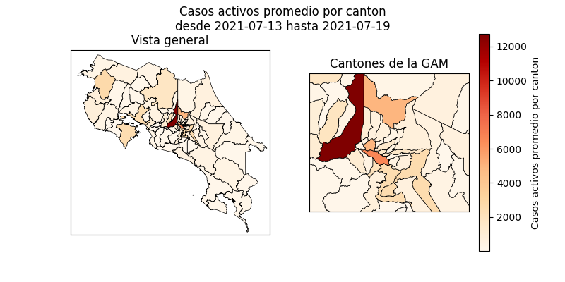

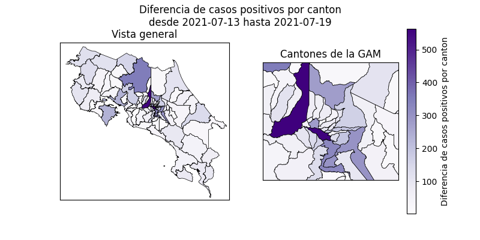

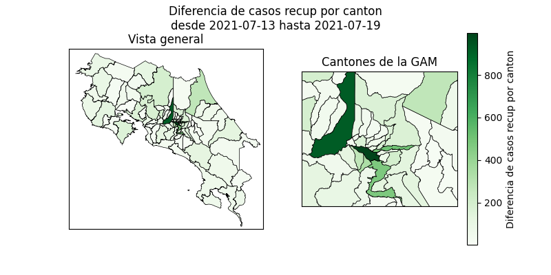

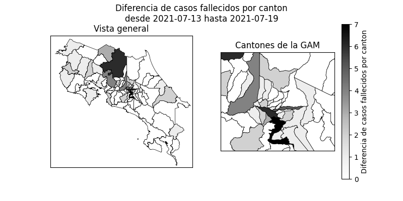

## Una versión automatizada del programa

Se ha implementado una versión automatizada del programa para que el usuario no tenga que estar descargando archivos cada vez que se requiere generar un reporte del día más reciente. Los cambios a realizar son mínimas y se realizan en el método `agregar_datos()`:

```python
    def agregar_datos(self):
        self.agregar_geodata('cantones', '../Datos/costa_rica_cantones.geojson')

        fecha = get_str_fecha(self.fecha_max)

        anio_corto = fecha.get_anio_str(corto=True)
        anio = fecha.get_anio_str()
        mes = fecha.get_mes_str()
        dia = fecha.get_dia_str()

        hojas = {'positivos': '2_1CANT_ACUMULADOS', 'recuperados': '2_2 CANT_RECUPERADOS', 'fallecidos': '2_3 CANT_FALLECIDOS', 'activos': '2_4 CANT_ACTIVOS'}
        enlace = 'http://geovision.uned.ac.cr/oges/archivos_covid/{}_{}_{}/{}_{}_{}_EXCEL_SERIES.xlsx'.format(anio, mes, dia, mes, dia, anio_corto)

        for indicador in self.indicadores:
            self.agregar_excel(indicador, enlace, hoja=hojas[indicador])
```

Dado a que los tildes en el excel vienen correctos, la línea`self.agregar_csv('nombres', '../Datos/costa_rica_cantones_nombres.csv')` ha sido removida del código. También se ha removido la línea `self.lista_df[indicador].canton = self.lista_df['nombres']` del método `limpiar_datos()` por la misma razón.

### Ejecución del programa automatizado

La ejecución del programa permanece igual comparado con el programa que utilizó archivos locales. Como prueba, se corre el código para el día de hoy (21 de julio de 2021):

```python
Data = DFs(mostrar_graficas=True, verboso=True)
Data.main()
```

### Resultados del programa automatizado

Los resultados son entonces:

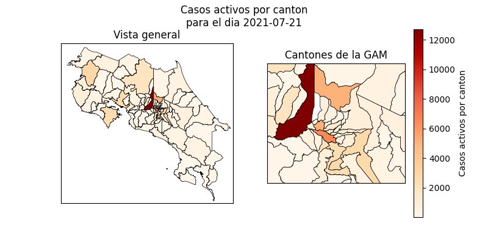

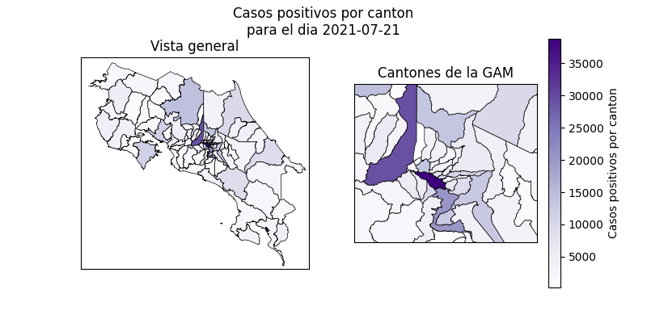

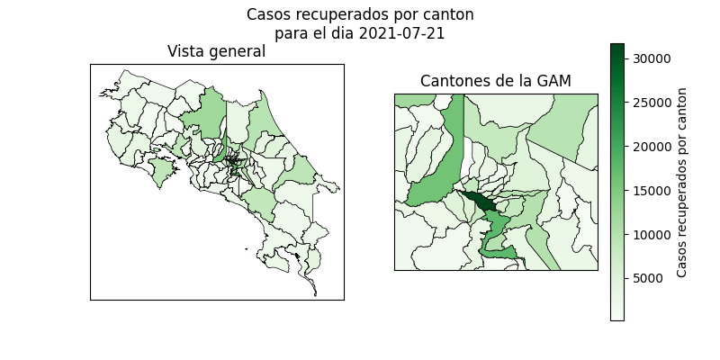

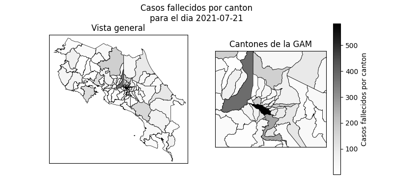